# MidtermPractice

### 2.3 Remove data plot and ACF plot

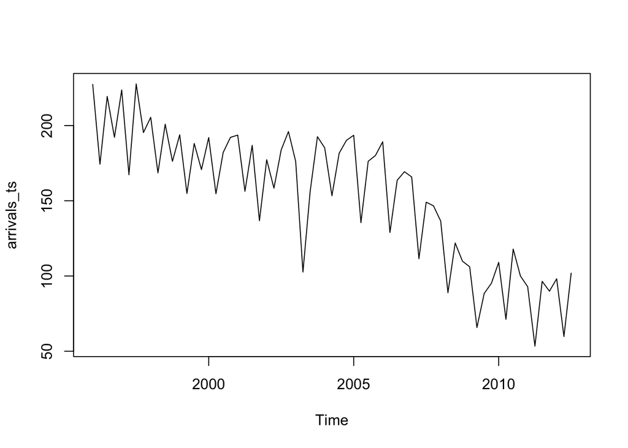

```r
arrivals_ts <- window(arrivals_ts_t, start = c(1996,1))

plot(arrivals_ts)
```

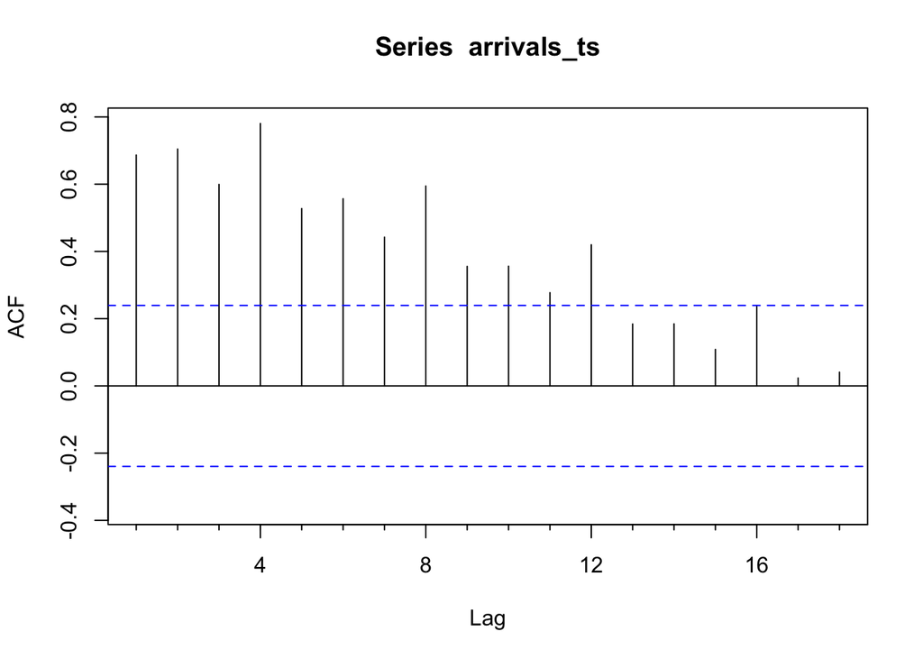

```r
Acf(arrivals_ts)
```

### 2.4 Summary of ACF Plot Observations

The **Autocorrelation Function (ACF)** plot for the Japan tourist arrivals time series shows the following characteristics:

- **Strong positive autocorrelation at small lags**, gradually decreasing as lag increases.  
  This pattern confirms the **presence of a long-term trend** in the data — consecutive observations are highly correlated.
- **Repeating spikes at lag multiples** indicate a **seasonal component** with a quarterly frequency.  
  This aligns with the dataset’s quarterly nature and the seasonal peaks observed in the time series plot.

Overall, the ACF plot supports the earlier findings that the data exhibits both **trend** and **seasonality**